# Effects of Loan Characteristics on BorrowerRate

## by Princess Obazee

## Investigation Overview

In this investigation, I wanted to look at the characteristics of Loans that could be used to predict the BorrowerRate. the main focus is the features that could affect the BorrowerRate, which are LoanOriginalAmount, ProsperRating (Alpha), Term, and StatedMonthlyIncome.

## Dataset Overview

The dataset consisted of 113,937 loans with 81 variables on each loan, including loan amount, borrower rate (or interest rate), current loan status, borrower income, and many others. 28,812 data points from the CreditGrade variable was used to fill the null values in the ProsperRating (Alpha) feature as these data points are Ratings for pre-2009 loans. 66 data points were removed from the dataset from the analysis due to very large stated monthly income seemed as outliers and missing borrower APR information.

# Distribution of BorrowerRate

The BorrowerRate or Interest Rate distribution looks roughly multimodal, with one peak at 16%, a very high peak at 32%, and a small peak at 36%.

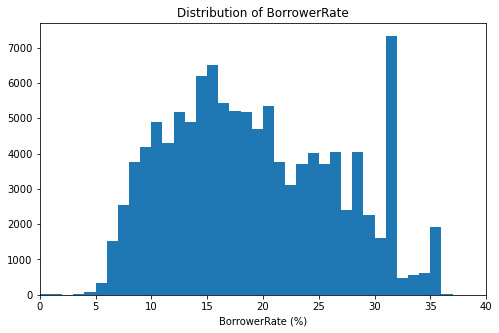

# Distribution of LoanOriginalAmount

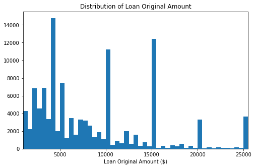

# BorrowerRate vs LoanOriginalAmount

The range of the BorrowerRate decreases as the LoanOriginalAmount increases. This indicates a negative correlation between the BorrowerRate and LoanOriginalAmount.

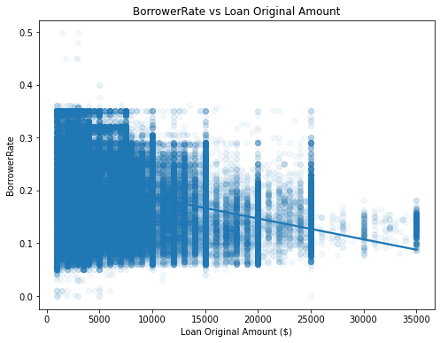

# BorrowerRate vs ProsperRating (Alpha)

The BorrowerRate gradually decreases as borrowers have better Prosper ratings. Borrowers with the best Prosper ratings have the lowest BorrowerRate. This indicates Prosper rating has a strong effect on BorrowerRate.

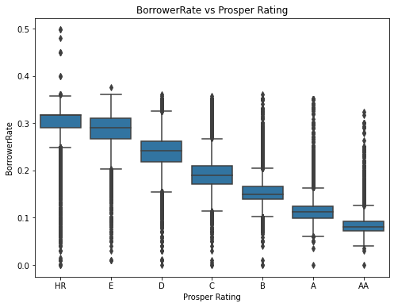

# BorrowerRate and LoanOriginalAmount by ProsperRating (Alpha)

The LoanOriginalAmount increases as the ProsperRating (Alpha) becomes higher. The BorrowerRate gradually decreases as the credit rating gets better.

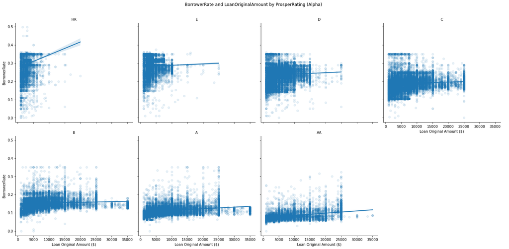

# BorrowerRate and ProsperRating (Alpha) by Term

The BorrowerRate decreases as the ProsperRating gets better. Interestingly, 60 month tenured loans generally have higher BorrowerRate than other tenured loans as the Rating gets better except for the HR rating where the BorrowerRate is the highest with only the 36 month termed loan.

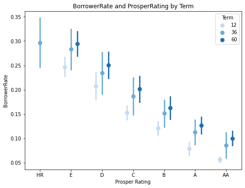